# Personal Loan Prediction

Ian Donovan

6/23/2020

```r
setwd("C:/Users/ian/Documents/STAT 331")
```

# Introduction

This analysis uses publicly available data from Universal Bank in an attempt to predict whether a customer will accept a personal loan offer extended by the bank.

```r
library(dplyr)
library(tidyr)
library(ggplot2)
library(randomForest)
library(caret)
library(ROCR)
library(class)
library(e1071)
library(RSNNS)
library(xgboost)
library(RColorBrewer)
library(devtools)
source_url('https://gist.githubusercontent.com/fawda123/7471137/raw/466c1474d0a505ff044412703516c34f1a4684a5/nnet_plot_update.r') #we use this to plot the network
```

## Loading the Data

Since ID and Zip code will not be meaningful for this analysis we remove them from the dataset.

```r
loans = read.csv('UniversalBank.csv')
  head(loans);
```

```
##   ID Age Experience Income ZIP.Code Family CCAvg Education Mortgage
## 1  1  25          1     49    91107      4   1.6         1        0
## 2  2  45         19     34    90089      3   1.5         1        0
## 3  3  39         15     11    94720      1   1.0         1        0
## 4  4  35          9    100    94112      1   2.7         2        0
## 5  5  35          8     45    91330      4   1.0         2        0
## 6  6  37         13     29    92121      4   0.4         2      155
##   Personal.Loan Securities.Account CD.Account Online CreditCard
## 1             0                  1          0      0          0
## 2             0                  1          0      0          0
## 3             0                  0          0      0          0
## 4             0                  0          0      0          0
## 5             0                  0          0      0          1
## 6             0                  0          0      1          0
```

```r
  loans = select(loans, -1, -5); # Remove ID, Zip Code
```

## Test Train Split

```r
set.seed(1)
  train = sample(1:nrow(loans), .8*nrow(loans))
  test = -train;
```

# Exploratory Data Analysis

## Summary Statistics

It looks like we will want to use one-hot encoding for education since this variable appears to be catagorical with 3 levels, we will create dummies after the EDA.

```r
mean = apply(loans, 2, mean)
  median = apply(loans, 2, median)
  sd = apply(loans, 2, sd)
  min = apply(loans, 2, min)
  max = apply(loans, 2, max);

  rbind(mean, median, sd, min, max);
```

```
##             Age Experience    Income   Family     CCAvg Education Mortgage
## mean   45.33840   20.10460  73.77420 2.396400  1.937938 1.8810000  56.4988
## median 45.00000   20.00000  64.00000 2.000000  1.500000 2.0000000   0.0000
## sd     11.46317   11.46795  46.03373 1.147663  1.747659 0.8398691 101.7138
## min    23.00000   -3.00000   8.00000 1.000000  0.000000 1.0000000   0.0000
## max    67.00000   43.00000 224.00000 4.000000 10.000000 3.0000000 635.0000
##        Personal.Loan Securities.Account CD.Account    Online CreditCard
## mean       0.0960000          0.1044000  0.0604000 0.5968000  0.2940000
## median     0.0000000          0.0000000  0.0000000 1.0000000  0.0000000
## sd         0.2946207          0.3058093  0.2382503 0.4905893  0.4556375
## min        0.0000000          0.0000000  0.0000000 0.0000000  0.0000000
## max        1.0000000          1.0000000  1.0000000 1.0000000  1.0000000
```

## Distributions

It seems strange that there are negative values for experience we will take a closer look by plotting the distribution. The experience variable has a max of 43 and appears continuous rather than catagorical, we may want to consider dropping these negative observations. Education has 3 levels and is a catagorical variable in this dataset.

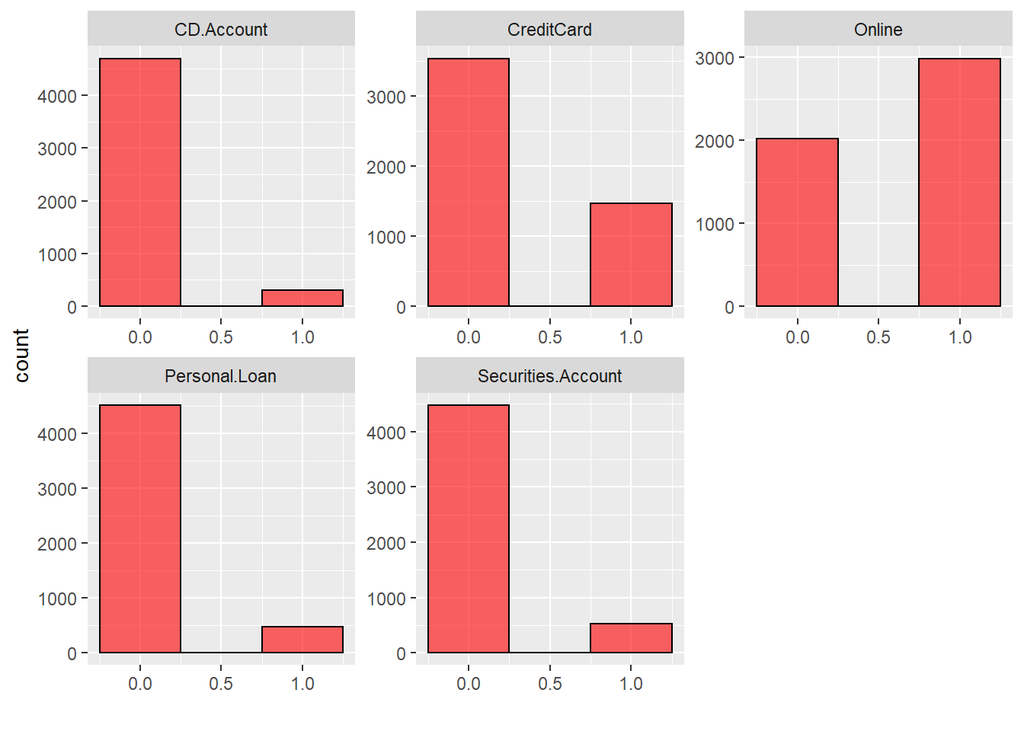

```r
maxs = sapply(loans, max)
binary_feats = loans[which(maxs == 1)]
cont_feats = loans[which(maxs != 1)]

binary.dta = gather(binary_feats) # Transforming the data into long format for plotting
cont.dta = gather(cont_feats)

ggplot(binary.dta, aes(value)) +
  geom_histogram(bins = 3, col='black', fill='red', alpha=.6) +
  facet_wrap(~key, scale=c('free')) +
  xlab('')
```

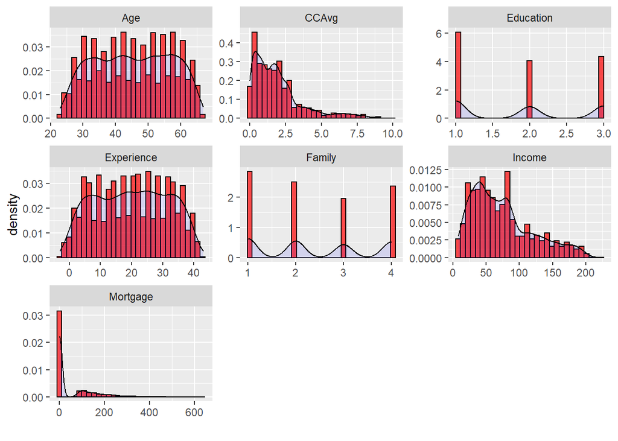

```r
ggplot(cont.dta, aes(value)) +
  geom_histogram(aes(y=..density..), bins=30, col='black', fill='red', alpha=.7) +
  facet_wrap(~key, scale='free') +
  geom_density(alpha=.1,fill='blue') +
  xlab('')
```

## Heatmap/Correlation Matrix

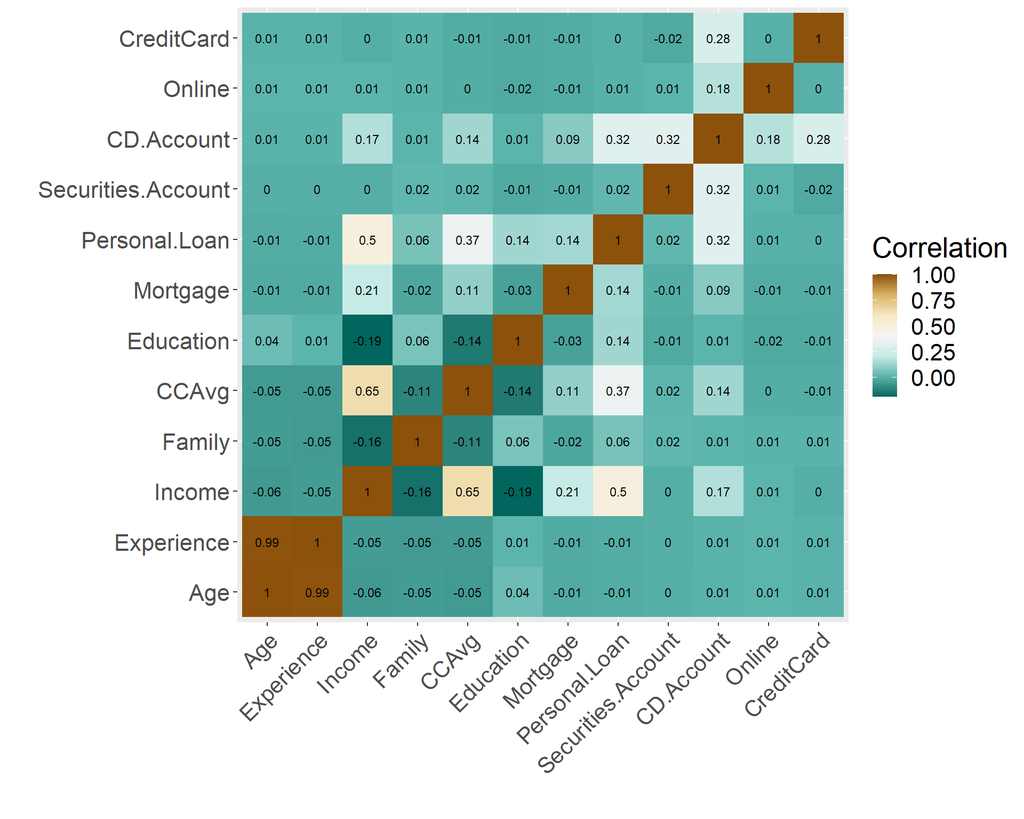

```r
x1 = names(loans)
x2 = names(loans)
  data.plot = expand.grid(x=x1, y=x2);

  data.plot$Correlation = as.vector(cor(loans));


  ggplot(data.plot, aes(x,y, fill=Correlation)) +
    geom_tile() +
    scale_fill_distiller(palette='BrBG') +
    theme(text = element_text(size=20,color='black'),
      axis.text.x = element_text(angle=45, hjust=1)) +
    xlab('') +
    ylab('') +
    geom_text(aes(x,y,label= round(Correlation, 2)), color='black', size=3);
```

Since experience and age are highly correlated it may help our model performance if we remove one of these variables. I removed the experience variable instead of age because of the ambiguous negative values in experience.

```r
loans = loans[,-2];
```

## Boxplot

Clearly there is a large difference in loan acceptance between income groups. High income alone did not guarantee loan acceptance however people making below ~100K/year almost never accept the offer.

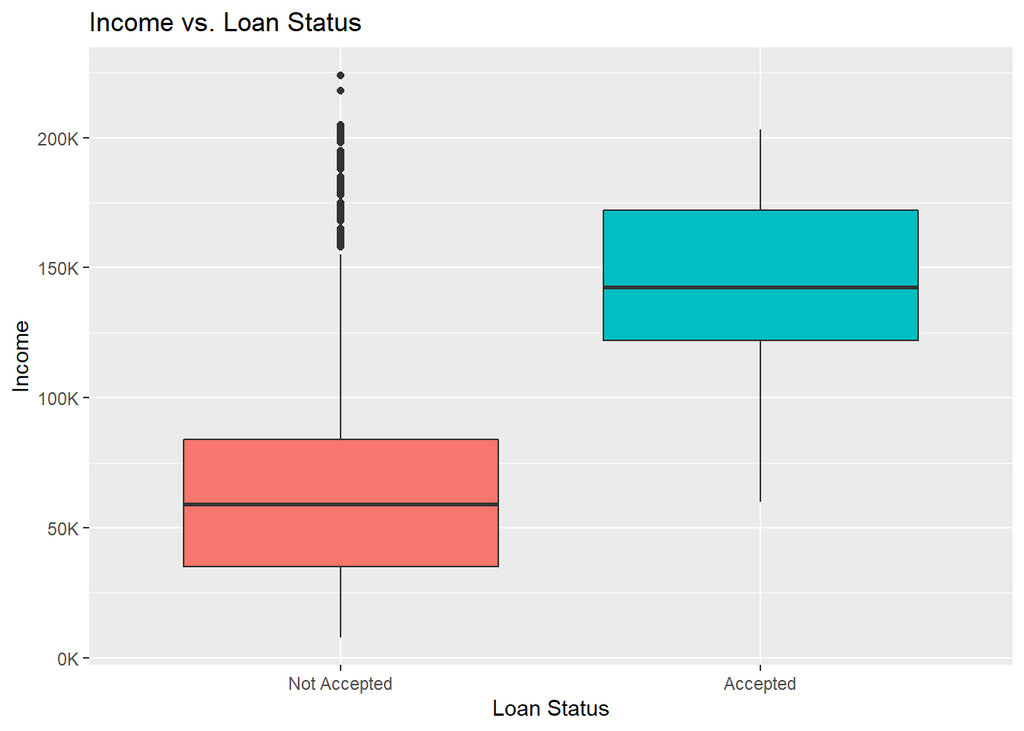

```r
ggplot(loans, aes(Income, factor(Personal.Loan), fill=factor(Personal.Loan))) +
  geom_boxplot() +
  coord_flip() +
  theme(legend.position="none") +
  scale_y_discrete(name='Loan Status', labels=c("Not Accepted", "Accepted")) +
  scale_x_continuous(name='Income', breaks=seq(0,200,by=50),labels=paste(seq(0,200, 50), 'K', sep=''))+
  labs(title = "Income vs. Loan Status");
```

# Classification Models

## Data Preparation

Earlier we noticed that education appears to be a catagorical variable in this dataset, here we will create a model matrix with dummies for the levels of education.

```r
dta.temp = loans
dta.temp$Education = factor(dta.temp$Education)
feats.temp = model.matrix(Personal.Loan~.,data=dta.temp)[,-1]
resp.temp = loans$Personal.Loan

one_hot = data.frame(feats.temp, 'Personal.Loan'=resp.temp);

temp.loans = one_hot
temp.loans$Personal.Loan = ifelse(temp.loans$Personal.Loan==1, 'Accepted', 'Not_Accepted');
```

Here we use min max scaling to normalize the dataset, later we will want to have this on hand.

```r
maxs <- apply(one_hot[,], 2, max)
mins <- apply(one_hot[,], 2, min);

  scaled.data <- as.data.frame(scale(one_hot[,],center = mins, scale = maxs - mins));
```

## Logistic Regression

```r
set.seed(1)

  glm.fit = glm(factor(Personal.Loan)~., data=temp.loans[train,], family='binomial') # Fitting on the training set

  glm.probs = predict(glm.fit, temp.loans[test,], type='response') # Predicting on the test set

  contrasts(factor(temp.loans$Personal.Loan));
```

```
##              Not_Accepted
## Accepted                0
## Not_Accepted            1
```

### ROC: Logistic Regression

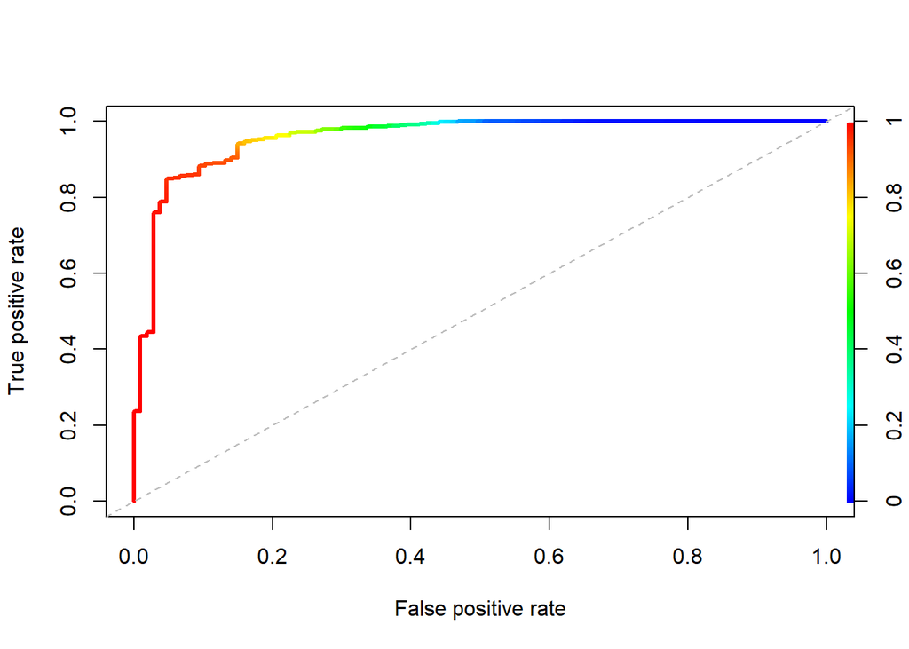

```r
pred = prediction(glm.probs, factor(temp.loans[test,12]))
perf = performance(pred,"tpr", "fpr")
{plot(perf, colorize= T, lwd=3)
abline(a=0,b=1, col='grey', lty=2)};
```

```r
  auc_ROCR = performance(pred, "auc")
  auc_ROCR.glm = auc_ROCR@y.values[[1]]
  auc_ROCR.glm;
```

```
## [1] 0.9583469
```

```r
  cuts = performance(pred,'acc') # returns an object full of performance metrics
  cutoffs = cuts@x.values[[1]]
  accuracy = cuts@y.values[[1]];

  which(accuracy==max(accuracy)) # find the cutoff that produces the best accuracy
```

```
## [1] 904 910 918 940
```

```r
  cutoffs[904];
```

```
##      3569
## 0.6280955
```

### Confusion Matrix: Logistic Regression

We are able to achieve a high auc of .958 but from the confusion matrix we can see that we classified quite a few observations who accepted their loan offer as ‘not accepted’, these are known as false negatives. Since the goal is to increase the number of accepted loans and making an offer has little cost associated for the bank we would rather have a few more false positives than false negatives. We don’t want to send offers to people who have a very low probability of accepting. If we can increase the recall without losing too much precision the bank may be able to save a significant amount of money.

```r
pred.glm = ifelse(glm.probs > 0.6280955, 'Not_Accepted','Accepted') #assign labels based on the threshold that maximizes accuracy

  table(pred.glm, temp.loans[test,12]) # Confusion Matrix
```

```
##
## pred.glm       Accepted Not_Accepted
##   Accepted           78           19
##   Not_Accepted       29          874
```

```r
  glm.acc = 1-mean(pred.glm!=temp.loans[test,12]); #  Accuracy = true pos + true neg / (true pos + true neg + false pos + false neg)
  glm.rec = 78/(78+29) #recall = TP/ TP + FN
  glm.pcn = 78/(78+19) #precision = TP / TP + FP

  glm.table = data.frame('Model'='Logistic Regression','Accuracy'= glm.acc, 'Recall'=glm.rec, 'Precision'= glm.pcn, 'AUC' = auc_ROCR.glm)
  glm.table
```

```
##                 Model Accuracy   Recall Precision       AUC
## 1 Logistic Regression    0.952 0.728972 0.8041237 0.9583469
```

## Random Forest

### Grid Search: Random Forest

Instead of setting mtry=sqrt(p) we will use a grid search to determine the optimal value. It looks like setting mtry=5 produces the best auc result.

```r
set.seed(1)

control = trainControl(method="cv",
                       number=10,
                       repeats = 3,
                       search="grid",
                       classProbs = TRUE,
                       summaryFunction = twoClassSummary)
tunegrid = expand.grid(.mtry=c(1:11))
rf_gridsearch = caret::train(factor(Personal.Loan)~.,
                       data=temp.loans[train,],
                       method="rf",
                       metric="ROC",
                       tuneGrid=tunegrid,
                       trControl=control,
                       ntree=50);

print(rf_gridsearch)
```

```
## Random Forest
##
## 4000 samples
##   11 predictor
##    2 classes: 'Accepted', 'Not_Accepted'
##
## No pre-processing
## Resampling: Cross-Validated (10 fold)
## Summary of sample sizes: 3600, 3601, 3600, 3600, 3600, 3600, ...
## Resampling results across tuning parameters:
##
##   mtry  ROC        Sens       Spec
##    1    0.9853009  0.1020626  1.0000000
##    2    0.9951120  0.8472973  0.9991720
##    3    0.9974959  0.8822902  0.9980686
##    4    0.9964699  0.8982219  0.9980701
##    5    0.9982319  0.9143670  0.9975184
##    6    0.9979660  0.9117354  0.9980693
##    7    0.9969916  0.9061878  0.9972421
##    8    0.9971563  0.9197013  0.9977931
##    9    0.9957443  0.9143670  0.9972421
##   10    0.9971349  0.9143670  0.9975176
##   11    0.9971352  0.9117354  0.9972429
##
## ROC was used to select the optimal model using the largest value.
## The final value used for the model was mtry = 5.
```

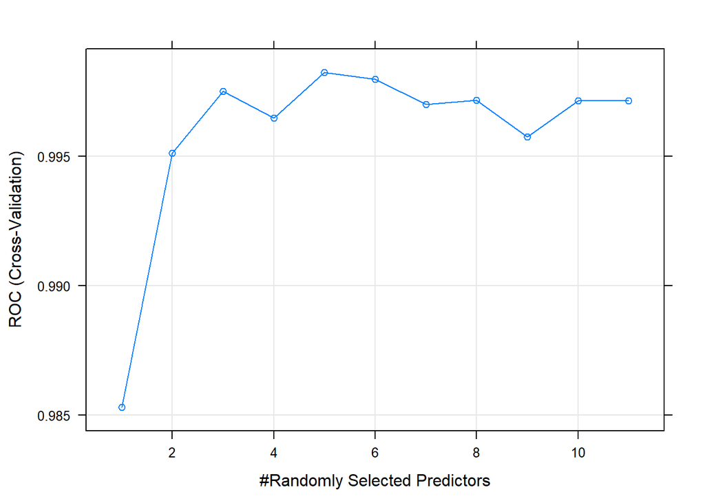

```r
plot(rf_gridsearch);
```

### Fitting the Final Model: Random Forest

After trying some different values for the number of trees to grow it appears that setting ntrees=~30 will yield the best results.

```r
set.seed(1)
control = trainControl(method="none", classProbs = T, summaryFunction = twoClassSummary)
tunegrid = expand.grid(.mtry=5)
rf_final = caret::train(factor(Personal.Loan)~.,
                       data=temp.loans[train,],
                       method="rf",
                       metric="ROC",
                       tuneGrid=tunegrid,
                       trControl=control,
                       importance=TRUE,
                       ntree=30);

varImp(rf_final)
```

```
## rf variable importance
##
##                    Importance
## Income                100.000
## Education2             64.057
## Education3             58.960
## Family                 52.870
## CCAvg                  27.202
## Age                    10.779
## CD.Account              7.516
## Online                  5.016
## CreditCard              3.316
## Mortgage                2.641
## Securities.Account      0.000
```

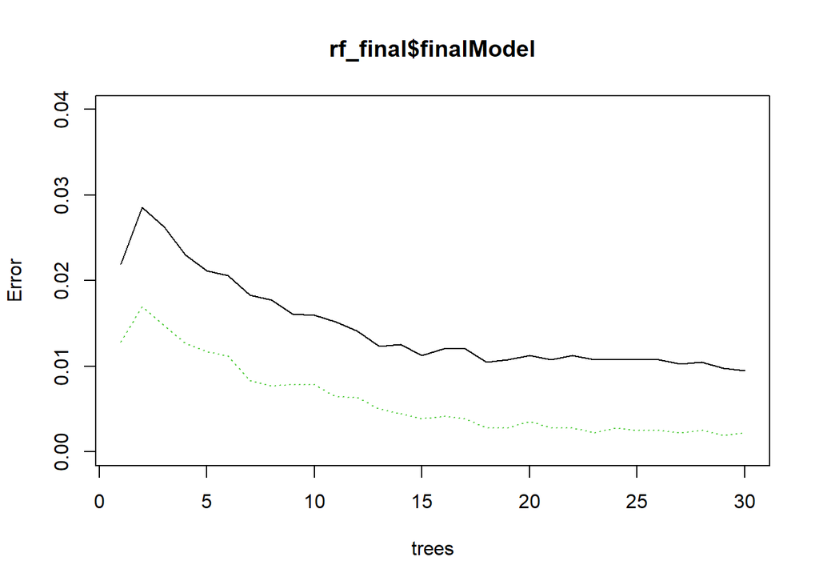

```r
plot(rf_final$finalModel, ylim=c(0,.04));
```

```r
pred.rf = predict(rf_final, temp.loans[test,], type='prob', n.trees=30);
```

### ROC: Random Forest

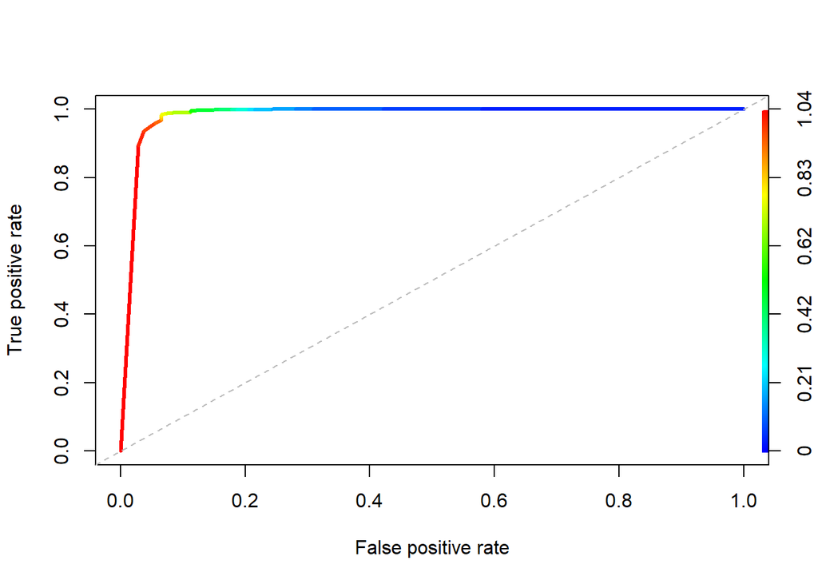

```r
pred = prediction(pred.rf[,2], factor(temp.loans[test,12]))
perf = performance(pred,"tpr", "fpr")
{plot(perf, colorize= T, lwd=3)
abline(a=0,b=1, col='grey', lty=2)};
```

```r
  auc_ROCR = performance(pred, "auc")
  auc_ROCR.rf = auc_ROCR@y.values[[1]]
  auc_ROCR.rf;
```

```
## [1] 0.9817637
```

```r
  cuts = performance(pred,'acc') # returns an object full of performance metrics
  cutoffs = cuts@x.values[[1]]
  accuracy = cuts@y.values[[1]];

  which(accuracy==max(accuracy)); # find the cutoff that gives the highest accuracy
```

```
## [1] 16
```

```r
  cutoffs[16];
```

```
## [1] 0.4666667
```

### Confusion Matrix: Random Forest

The Accuracy, AUC, precision and recall have all improved with this model. The increase in precision and recall suggest we can have higher confidence in our predictions from this model compared to the logistic regression. The precision here is extremely high, there were only 3 total false positives.

```r
pred.labs = ifelse(pred.rf[,2] > 0.4666667, 'Not_Accepted','Accepted')

  table(pred.labs, temp.loans[test,12])
```

```
##
## pred.labs      Accepted Not_Accepted
##   Accepted           94            3
##   Not_Accepted       13          890
```

```r
  rf.acc = 1-mean(pred.labs!=temp.loans[test,12]); # Accuracy
  rf.rec = 94/(94+13) #recall
  rf.pcn = 94/(94+3)  #Precison

  rf.table = data.frame('Model'='Random Forest','Accuracy'= rf.acc, 'Recall'=rf.rec, 'Precision'= rf.pcn, 'AUC'= auc_ROCR.rf)
  mod.table = rbind(rf.table, glm.table)
  mod.table
```

```
##                 Model Accuracy    Recall Precision       AUC
## 1       Random Forest    0.984 0.8785047 0.9690722 0.9817637
## 2 Logistic Regression    0.952 0.7289720 0.8041237 0.9583469
```

## Boosting

Here we create a full train test split to use with xgboost and caret.

```r
x.train = temp.loans[train,-12]
y.train = temp.loans[train,12];

x.test = temp.loans[test,-12]
y.test = temp.loans[test,12];
```

### Grid Search: Boosting

We start with a random set of parameters and find the best parameters. After that we “zoom in” around the best parameter to see if we can improve the performance even more. By performing our grid search in steps we can reduce computation time dramatically.

```r
set.seed(1)
xgb.grid = expand.grid( nrounds = c(6500,7500),
                        max_depth = 5,
                        eta = .001,
                        gamma = 0,
                        min_child_weight = 1,
                        colsample_bytree = 1,
                        subsample = c(.8,1));


fitControl = trainControl(method='cv', number= 10, classProbs = T,  summaryFunction = twoClassSummary);

xgb.cv = caret::train(x = x.train,
                       y= factor(y.train),
                       method='xgbTree',
                       metric='ROC',
                       trControl= fitControl,
                       tuneGrid= xgb.grid);

xgb.cv;
```

```
## eXtreme Gradient Boosting
##
## 4000 samples
##   11 predictor
##    2 classes: 'Accepted', 'Not_Accepted'
##
## No pre-processing
## Resampling: Cross-Validated (10 fold)
## Summary of sample sizes: 3600, 3601, 3600, 3600, 3600, 3600, ...
## Resampling results across tuning parameters:
##
##   subsample  nrounds  ROC        Sens       Spec
##   0.8        6500     0.9977425  0.9062589  0.9969674
##   0.8        7500     0.9976828  0.9062589  0.9972429
##   1.0        6500     0.9976273  0.9063300  0.9969674
##   1.0        7500     0.9976128  0.9115932  0.9969674
##
## Tuning parameter 'max_depth' was held constant at a value of 5
## Tuning
##  'colsample_bytree' was held constant at a value of 1
## Tuning
##  parameter 'min_child_weight' was held constant at a value of 1
## ROC was used to select the optimal model using the largest value.
## The final values used for the model were nrounds = 6500, max_depth = 5, eta
##  = 0.001, gamma = 0, colsample_bytree = 1, min_child_weight = 1 and subsample
##  = 0.8.
```

```r
#Best params First round
#eta   max_depth colsample_bytree  subsample  nrounds  ROC        Sens       Spec
#0.001 3         1.0               0.8        10000    0.9972747  0.9006126  0.9961387

#Best params second round
#eta     max_depth    nrounds      ROC        Sens       Spec
#0.001   5            8000    0.9976534  0.9062589  0.9972429

#Best params third round
#eta      max depth    nrounds      ROC        Sens       Spec
#0.001     5           7500    0.9976534  0.9062589  0.9972429

#Best params fourth round
#eta       max depth    nrounds      ROC        Sens       Spec  eta
#0.001      5           6500    0.9976534  0.9062589  0.9972429  0.001
```

### Fitting the Final Model

```r
set.seed(1)
xgb.grid = expand.grid( nrounds = 6500,
                        max_depth = 5,
                        eta = .001,
                        gamma = 0,
                        min_child_weight = 1,
                        colsample_bytree = 1,
                        subsample = .8);


fitControl = trainControl(method='none', classProbs = T, summaryFunction = twoClassSummary);

xgb.fit = caret::train(x = x.train,
                       y= factor(y.train),
                       method='xgbTree',
                       metric='ROC',
                       trControl= fitControl,
                       tuneGrid= xgb.grid);


boost.pred = predict(xgb.fit, x.test, type='prob');
```

### ROC: Boosted Model

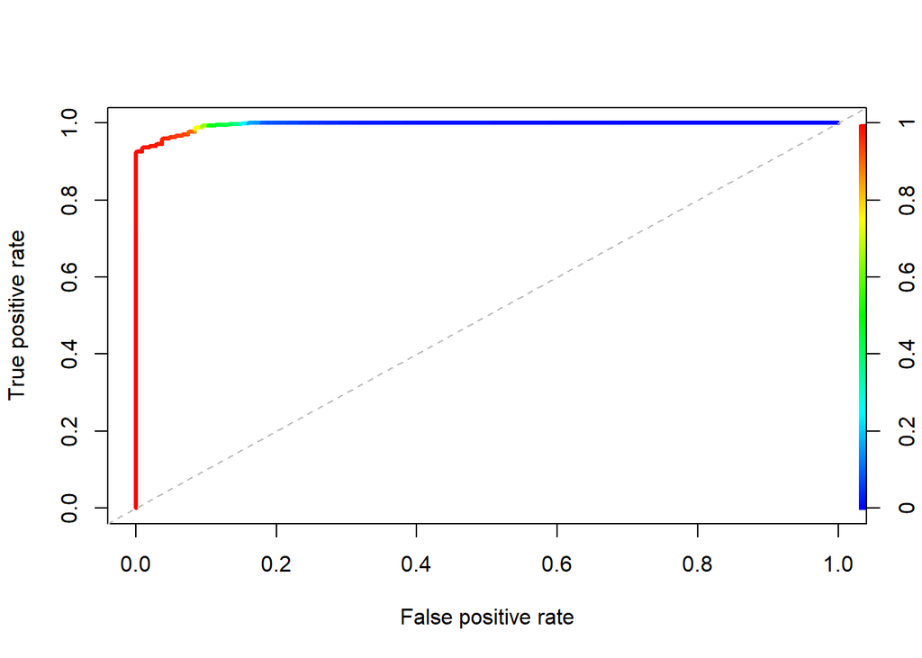

```r
pred = prediction(boost.pred[,2], factor(y.test))
perf = performance(pred,"tpr", "fpr")
{plot(perf, colorize= T, lwd=3)
abline(a=0,b=1, col='grey', lty=2)}
```

```r
  auc_ROCR = performance(pred, "auc")
  auc_ROCR.bst = auc_ROCR@y.values[[1]]
  auc_ROCR.bst # almost exactly 1
```

```
## [1] 0.99573
```

```r
  cuts = performance(pred,'acc') # returns an object full of performance metrics
  cutoffs = cuts@x.values[[1]]
  accuracy = cuts@y.values[[1]]

  which(accuracy==max(accuracy)) # find the cutoff that gives the highest accuracy
```

```
## [1] 828 830 832
```

```r
  cutoffs[828];
```

```
## [1] 0.650959
```

### Confusion Matrix: Boosted Model

```r
boost.labs = ifelse(boost.pred[,2] > 0.650959, 'Not_Accepted','Accepted')

  table(boost.labs, y.test)
```

```
##               y.test
## boost.labs     Accepted Not_Accepted
##   Accepted           97            7
##   Not_Accepted       10          886
```

```r
  xg.acc = 1-mean(boost.labs!=y.test); # Accuracy
  xg.rec = 97/(97+10) #Recall
  xg.pcn = 97/(97+7)  #Precision

  xg.table = data.frame('Model'='Gradient Boosted Model','Accuracy'= xg.acc, 'Recall'=xg.rec, 'Precision'= xg.pcn, 'AUC'= auc_ROCR.bst)
  mod.table = rbind(xg.table, mod.table)
  mod.table
```

```
##                    Model Accuracy    Recall Precision       AUC
## 1 Gradient Boosted Model    0.983 0.9065421 0.9326923 0.9957300
## 2          Random Forest    0.984 0.8785047 0.9690722 0.9817637
## 3    Logistic Regression    0.952 0.7289720 0.8041237 0.9583469
```

## K-Nearest Neighbors

We use the normalized data with min max scaling to improve performance, since KNN is calculating the distance between observations we want everything on the same scale.

```r
scaled.data$Personal.Loan = ifelse(scaled.data$Personal.Loan==1, 'Accepted', 'Not_Accepted');

  scale.train.x = scaled.data[train, -12]
  scale.train.y = scaled.data[train,12];

  scale.test.x = scaled.data[test, -12]
  scale.test.y = scaled.data[test, 12];
```

### Choosing K

Here the best auc was achieved using K=44.

```r
set.seed(1)

knn.grid = expand.grid(k=1:75);
fitControl = trainControl(method='cv', number= 5, classProbs = T,  summaryFunction = twoClassSummary);
knn.cv = caret::train(x = scale.train.x,
                        y= factor(scale.train.y),
                        method='knn',
                        metric='ROC',
                        trControl= fitControl,
                        tuneGrid= knn.grid);

  knn.cv$bestTune
```

```
##     k
## 44 44
```

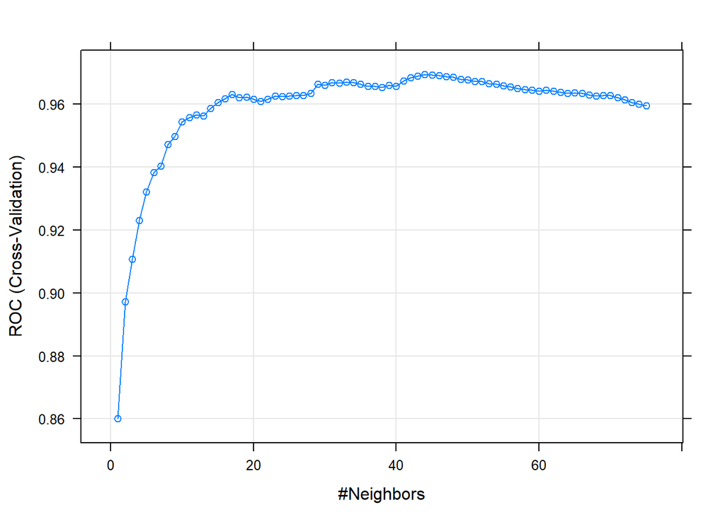

```r
  plot(knn.cv);
```

### Fitting the Best Model: KNN

```r
set.seed(1)

knn.pred= knn(scale.train.x, scale.test.x, factor(scale.train.y), k=44, prob=T)
knn.probs = attr(knn.pred, "prob");
```

### ROC: KNN

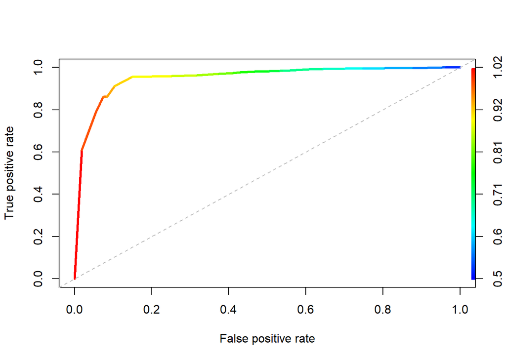

```r
pred = prediction(knn.probs, factor(scale.test.y))
perf = performance(pred,"tpr", "fpr")
{plot(perf, colorize= T, lwd=3)
abline(a=0,b=1, col='grey', lty=2)}
```

```r
  auc_ROCR = performance(pred, "auc") # returns the auc
  auc_ROCR.knn = auc_ROCR@y.values[[1]]
  auc_ROCR.knn
```

```
## [1] 0.9518058
```

```r
  cuts = performance(pred,'acc') # returns an object full of performance metrics
  cutoffs = cuts@x.values[[1]]
  accuracy = cuts@y.values[[1]]

  which(accuracy==max(accuracy)) # find the cutoff that produces the best result
```

```
## [1] 10
```

```r
  cutoffs[10];
```

```
## [1] 0.8863636
```

### Confusion Matrix: KNN

The performance of the KNN classifier in this example is slightly worse than the other models. The performance of KNN here is simmilar to that of the logistic regression,it appears there are better methods available for this problem.

```r
yhat.knn = ifelse(knn.probs > 0.8863636, 'Not_Accepted','Accepted')

  table(yhat.knn, scale.test.y)
```

```
##               scale.test.y
## yhat.knn       Accepted Not_Accepted
##   Accepted           91           39
##   Not_Accepted       16          854
```

```r
  knn.acc = 1-mean(yhat.knn!=scale.test.y); # accuracy
  knn.rec = 91/(91+16) #Recall
  knn.pcn = 91/(91+39) #Precision

  knn.table = data.frame('Model'='K-Nearest Neighbors','Accuracy'= knn.acc, 'Recall'= knn.rec, 'Precision'= knn.pcn, 'AUC'= auc_ROCR.knn)
  mod.table = rbind(knn.table, mod.table)
  mod.table;
```

```
##                    Model Accuracy    Recall Precision       AUC
## 1    K-Nearest Neighbors    0.945 0.8504673 0.7000000 0.9518058
## 2 Gradient Boosted Model    0.983 0.9065421 0.9326923 0.9957300
## 3          Random Forest    0.984 0.8785047 0.9690722 0.9817637
## 4    Logistic Regression    0.952 0.7289720 0.8041237 0.9583469
```

## Neural Network

### Grid Search: NN

```r
set.seed(1)
mlp_grid = expand.grid(layer1 = c(7, 10),
                       layer2 = c(7,10),
                       layer3 = 1)

fitControl = trainControl(method='cv', number= 10, repeats=3, classProbs = T,  summaryFunction = twoClassSummary)

mlp_cv = caret::train(x = scale.train.x,
                y = factor(scale.train.y),
                method='mlpML',
                trControl= fitControl,
                metric='ROC',
                linout= F,
                tuneGrid = mlp_grid);
mlp_cv;
```

```
## Multi-Layer Perceptron, with multiple layers
##
## 4000 samples
##   11 predictor
##    2 classes: 'Accepted', 'Not_Accepted'
##
## No pre-processing
## Resampling: Cross-Validated (10 fold)
## Summary of sample sizes: 3600, 3601, 3600, 3600, 3600, 3600, ...
## Resampling results across tuning parameters:
##
##   layer1  layer2  ROC        Sens       Spec
##    7       7      0.9783966  0.8877667  0.9897965
##    7      10      0.9757284  0.8576102  0.9931015
##   10       7      0.9783662  0.8603129  0.9933793
##   10      10      0.9800981  0.8930299  0.9928245
##
## Tuning parameter 'layer3' was held constant at a value of 1
## ROC was used to select the optimal model using the largest value.
## The final values used for the model were layer1 = 10, layer2 = 10 and layer3
##  = 1.
```

```r
#Best params
#layer1  layer2  layer3  ROC        Sens       Spec
#10       10     1       0.9800981  0.8930299  0.9928245
```

### Fitting the Best Model: NN

The best model used 10 hidden nodes in the first layer, 10 in the second, and 1 in the last. We skip using the caret package to make plotting the network a bit easier

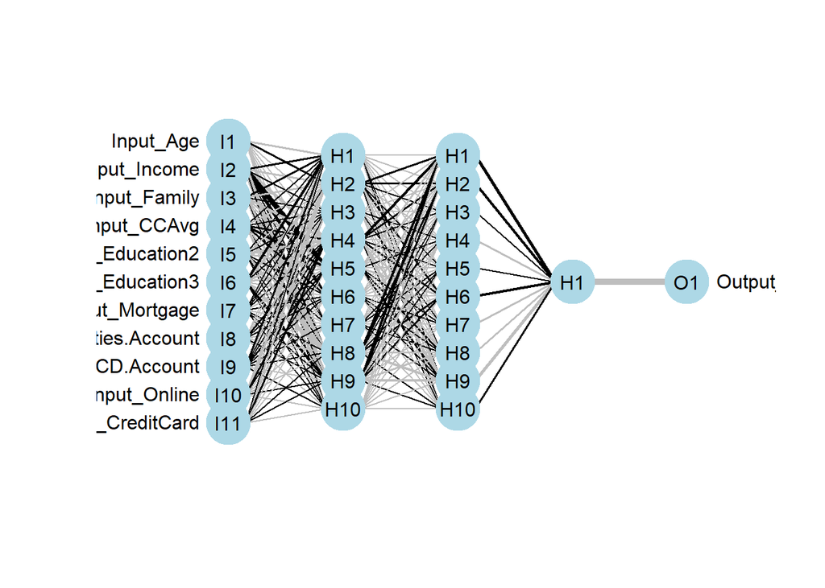

```r
set.seed(1)

train.numeric =ifelse(scale.train.y=='Accepted', 1, 0)
test.numeric =ifelse(scale.test.y=='Accepted', 1, 0)

mlp.fit = mlp(x=scale.train.x, y=train.numeric, size=c(10,10,1), linOut = F)

plot.nnet(mlp.fit)
```

```r
nn.probs = predict(mlp.fit, scale.test.x, type='prob');
```

### ROC: NN

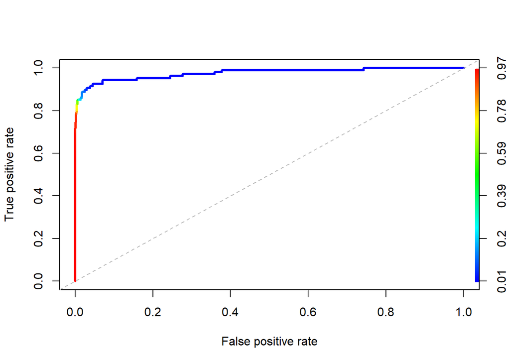

```r
pred = prediction(nn.probs, test.numeric)
perf = performance(pred,"tpr", "fpr")
{plot(perf, colorize= T, lwd=3)
abline(a=0,b=1, col='grey', lty=2)}
```

```r
  auc_ROCR = performance(pred, "auc") # returns the auc
  auc_ROCR.nn = auc_ROCR@y.values[[1]]
  auc_ROCR.nn
```

```
## [1] 0.9762117
```

```r
  cuts = performance(pred,'acc') # returns an object full of performance metrics
  cutoffs = cuts@x.values[[1]]
  accuracy = cuts@y.values[[1]]

  which(accuracy==max(accuracy)) # find the cutoff that produces the best result
```

```
## [1] 97
```

```r
  cutoffs[97];
```

```
## [1] 0.5361597
```

### Confusion Matrix: NN

Here we can see that the neural network is able to give us a model with an extremely low false positive rate, if we were to use this model we could be confident that people who are predicted to accept the loan offer will actually accept. Compared to the boosted model we have a few more false negatives, if our goal is to maximize the total number of loans accepted we could use another model or just send offers to everyone but the neural network and boosted model provide a good balance of both precision and recall.

```r
yhat.nn = ifelse(nn.probs > 0.5361597, 'Accepted','Not_Accepted')

  table(yhat.nn, scale.test.y)
```

```
##               scale.test.y
## yhat.nn        Accepted Not_Accepted
##   Accepted           90            5
##   Not_Accepted       17          888
```

```r
  nn.acc = 1-mean(yhat.nn!=scale.test.y) #Accuracy
  nn.rec = 90/(90+17) #Recall
  nn.pcn = 90/(90+5)  #Precision

  nn.table = data.frame('Model'='Neural Network: 3 Hidden Layers',
                        'Accuracy'= nn.acc,
                        'Recall'= nn.rec,
                        'Precision'= nn.pcn,
                        'AUC'= auc_ROCR.nn);

  mod.table = rbind(nn.table, mod.table)
  mod.table;
```

```
##                             Model Accuracy    Recall Precision       AUC
## 1 Neural Network: 3 Hidden Layers    0.978 0.8411215 0.9473684 0.9762117
## 2             K-Nearest Neighbors    0.945 0.8504673 0.7000000 0.9518058
## 3          Gradient Boosted Model    0.983 0.9065421 0.9326923 0.9957300
## 4                   Random Forest    0.984 0.8785047 0.9690722 0.9817637
## 5             Logistic Regression    0.952 0.7289720 0.8041237 0.9583469
```